# Spatial Point Patterns

Testing CSR with the Quadrat Method

Yang Li

2026-05-20

# Visualizations Can Be Misleading

Sometimes we see things that aren’t there.

**The Kanizsa Triangle**

[figure not shown]

**The Müller-Lyer Illusion**

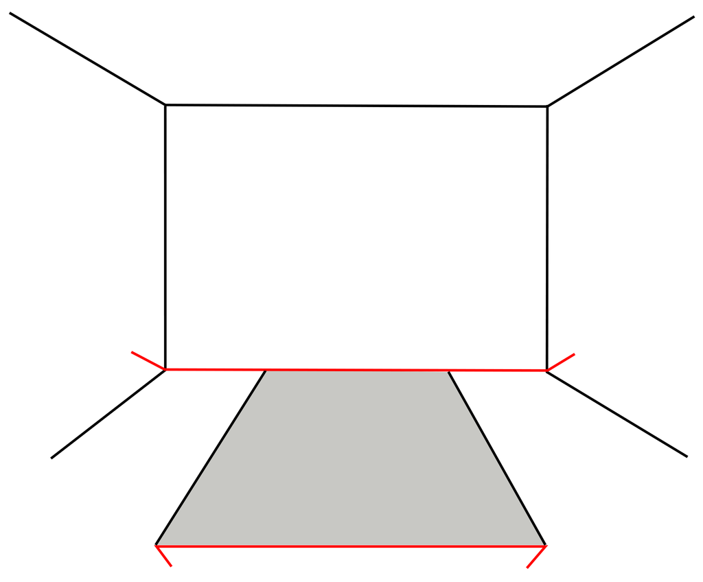

**Aggregated, Random, or Regular?**

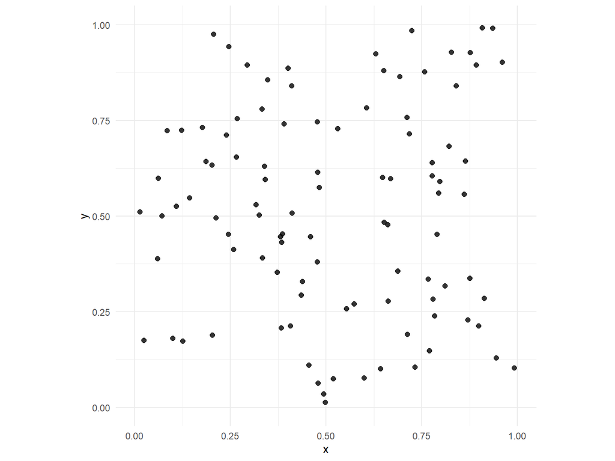

# What is Statistical Testing?

A **statistical test** is a formal procedure used to determine whether there is enough evidence in a sample of data to support a claim about a population.

The general idea is:

> Is the observed effect real, or could it have occurred simply by random chance?

**Example**

Suppose researchers want to determine whether the average systolic blood pressure of patients at a clinic differs from the standard reference value of 120 mmHg.

- **Null hypothesis** $H_0: \mu=120$ versus **alternative hypothesis** $H_1: \mu\neq 120$.
- Need to draw a sample of size $n$ from the population and measure their systolic BP.
- Select the test statistic $\bar{x}$.
- If $\bar{x}$ is close to 120, then don’t reject $H_0$. If $\bar{x}$ is far away from 120, reject $H_0$ and claim $H_1$.
  - Rejection region: $\bar{x}$ in the rejection region $\Rightarrow$ rejection
  - $p$-value

# The p-value

The **p-value** measures the probability of observing data as extreme as, or more extreme than, the sample data, assuming that the null hypothesis is true.

A small p-value gives evidence against the null hypothesis.

A common decision rule is:

$$\text{Reject } H_0 \quad \text{if} \quad p < \alpha$$

For example, if $\alpha = 0.05$, then:

- if $p < 0.05$, reject $H_0$;
- if $p \geq 0.05$, fail to reject $H_0$.

# Example: Blood Pressure Study

Suppose researchers want to test whether the average systolic blood pressure in a population differs from 120 mmHg.

The hypotheses are:

$$H_0: \mu = 120$$

$$H_a: \mu \neq 120$$

Suppose a sample is collected and a one-sample t-test gives:

$$p = 0.012$$

Since

$$0.012 < 0.05,$$

we reject $H_0$.

Therefore, we conclude that there is statistically significant evidence that the mean systolic blood pressure differs from 120 mmHg.

# R Example

The following code simulates systolic blood pressure data and performs a one-sample t-test.

```r
set.seed(123)

blood_pressure <- rnorm(
  n = 30,
  mean = 125,
  sd = 12
)

t.test(
  blood_pressure,
  mu = 120
)
```

```
##
##  One Sample t-test
##
## data:  blood_pressure
## t = 2.0633, df = 29, p-value = 0.04814
## alternative hypothesis: true mean is not equal to 120
## 95 percent confidence interval:
##  120.0389 128.8306
## sample estimates:
## mean of x
##  124.4348
```

# Testing CSR with the Quadrat Method

Given a point pattern, the first question is often whether there is any evidence to allow rejection of the null hypothesis of complete spatial randomness (CSR).

The **quadrat method** partitions the study region into $r$ rows and $c$ columns, which define $m=rc$ non-overlapping subregions of equal area.

Null hypothesis $H_0: \text{CSR}$ and alternative hypothesis $H_1: \text{not CSR}$.

The test statistic is

$$X^2 = \sum_{i=1}^m \frac{(\mbox{observed}_i -
\mbox{expected})^2}{\mbox{expected}} =
\sum_{i=1}^m \frac{(n_i - n^*)^2}{n^*}.$$

Under $H_0$, $X^2$ follows a chi-squared distribution with degrees of freedom $m-1$, $X^2\sim \chi^2_{m-1}$.

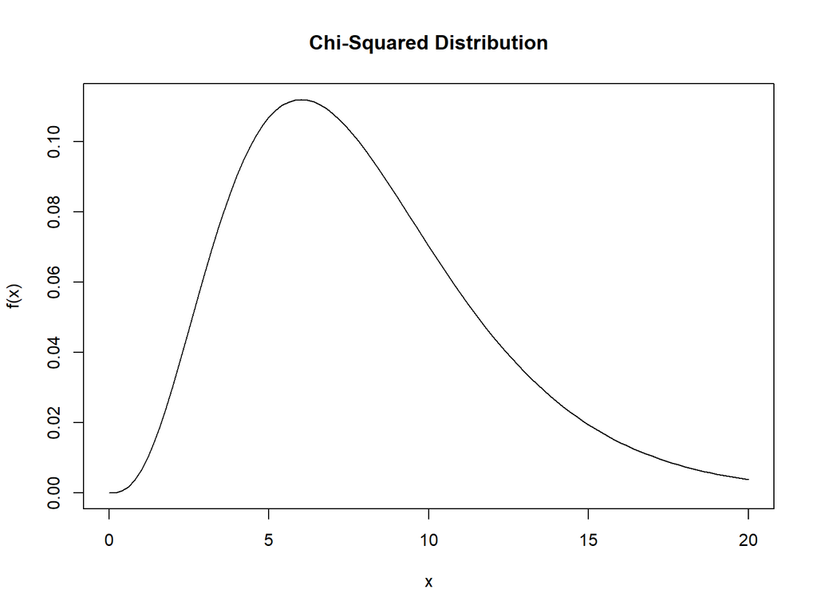

- If $X^2$ is too big, the pattern is aggregated.
- If $X^2$ is too small, the pattern is regular.
- Otherwise, the pattern is CSR.

# Quadrat Method in R

### Generating a Point Pattern

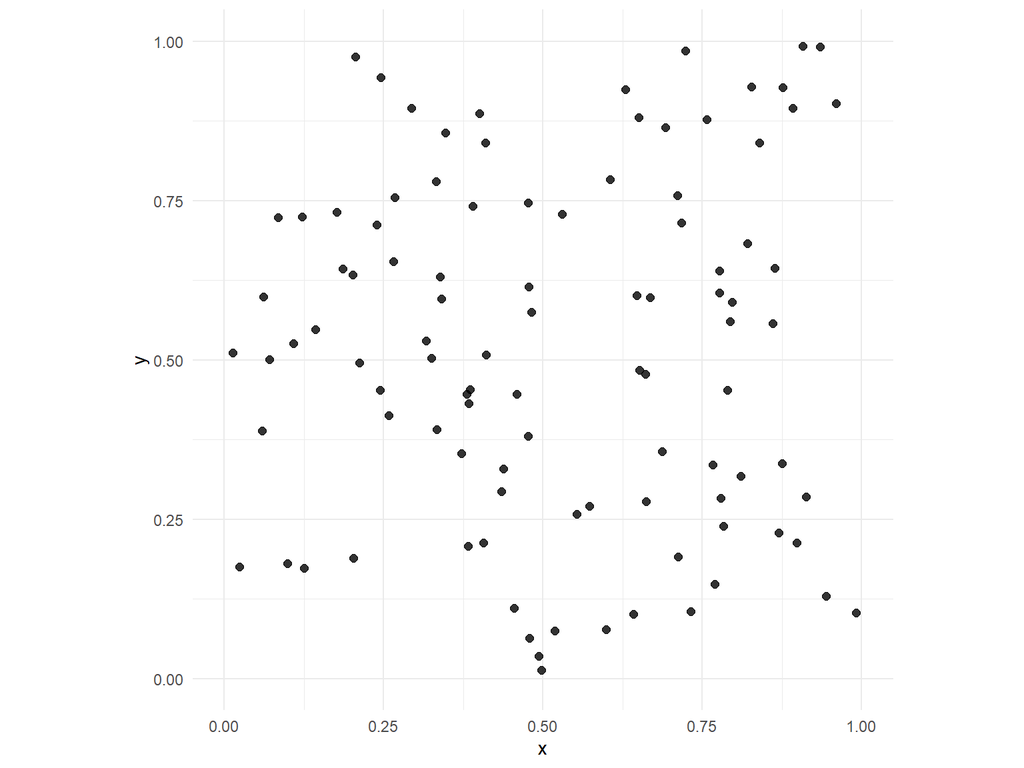

```r
suppressPackageStartupMessages({
  library(ggplot2)
  library(spatstat.geom)
  library(spatstat.explore)
})

set.seed(1)

n_random <- 100

random_df <- data.frame(
  x = runif(n_random, 0, 1),
  y = runif(n_random, 0, 1),
  pattern = "Random"
)

ggplot(random_df, aes(x = x, y = y)) +
  geom_point(size = 2, alpha = 0.8) +
  coord_equal(xlim = c(0, 1), ylim = c(0, 1)) +
  labs(x = "x", y = "y") +
  theme_minimal()
```

### Convert to a `ppp` Object

```r
random_ppp <- ppp(
  x = random_df$x,
  y = random_df$y,
  window = owin(
    xrange = c(0, 1),
    yrange = c(0, 1)
  )
)
random_ppp
```

```
## Planar point pattern: 100 points
## window: rectangle = [0, 1] x [0, 1] units
```

A `ppp` object in `spatstat` means a **planar point pattern** object. It is the main data format that `spatstat` uses for spatial point pattern analysis. A `ppp` object stores:

- the $x$-coordinates of the points,
- the $y$-coordinates of the points,
- the observation window (`owin`),
- optional marks, such as point type or group label.

### Counting

```r
q_counts <- quadratcount(random_ppp, nx = 4, ny = 4)
q_counts
```

```
##             x
## y            [0,0.25] (0.25,0.5] (0.5,0.75] (0.75,1]
##   (0.75,1]          2          6          6        8
##   (0.5,0.75]       11         10          4        7
##   (0.25,0.5]        3         10          6        6
##   [0,0.25]          4          6          5        6
```

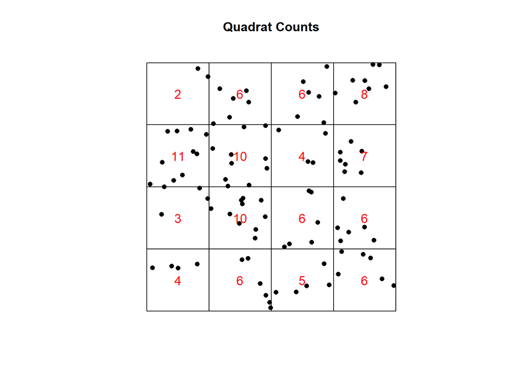

```r
plot(random_ppp, pch = 16, cols = "black", main = "Quadrat Counts")
plot(q_counts, add = TRUE, col = "red", cex = 1.2)
```

### Quadrat Test for CSR

On average, each quadrat has $100/16=6.25$ dots. The test statistic

$$X^2=\sum_{i=1}^{16}\frac{(O_i-6.25)^2}{6.25}=15.2$$

```r
q_test <- quadrat.test(random_ppp, nx = 4, ny = 4)
q_test
```

```
##
##  Chi-squared test of CSR using quadrat counts
##
## data:  random_ppp
## X2 = 15.2, df = 15, p-value = 0.8742
## alternative hypothesis: two.sided
##
## Quadrats: 4 by 4 grid of tiles
```

The $p$-value is large so we won’t reject $H_0$. This means there is not strong evidence against complete spatial randomness.

The point pattern is generated with completely spatial randomness. It is not surprising that we don’t reject CSR.

# Quadrat Test on an Aggregated Pattern

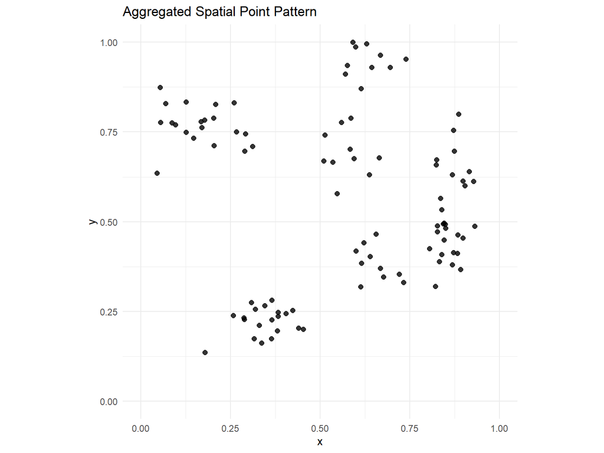

```r
set.seed(1)
n_clusters <- 10
points_per_cluster <- 10

cluster_centers <- data.frame(
  cx = runif(n_clusters, 0.05, 0.95),
  cy = runif(n_clusters, 0.05, 0.95)
)

aggregated_df <- do.call(
  rbind,
  lapply(1:n_clusters, function(k) {
    data.frame(
      x = rnorm(points_per_cluster, cluster_centers$cx[k], sd = 0.05),
      y = rnorm(points_per_cluster, cluster_centers$cy[k], sd = 0.05),
      cluster = k
    )
  })
)

aggregated_df$x <- pmin(pmax(aggregated_df$x, 0), 1)
aggregated_df$y <- pmin(pmax(aggregated_df$y, 0), 1)
aggregated_df$pattern <- "Aggregated"

ggplot(aggregated_df, aes(x = x, y = y)) +
  geom_point(size = 2, alpha = 0.8) +
  coord_equal(xlim = c(0, 1), ylim = c(0, 1)) +
  labs(
    title = "Aggregated Spatial Point Pattern",
    x = "x",
    y = "y"
  ) +
  theme_minimal()
```

```r
aggregated_ppp <- ppp(
  x = aggregated_df$x,
  y = aggregated_df$y,
  window = owin(
    xrange = c(0, 1),
    yrange = c(0, 1)
  )
)
aggregated_ppp
```

```
## Planar point pattern: 100 points
## window: rectangle = [0, 1] x [0, 1] units
```

### Counting

```r
aggregated_counts <- quadratcount(aggregated_ppp, nx = 4, ny = 4)
aggregated_counts
```

```
##             x
## y            [0,0.25] (0.25,0.5] (0.5,0.75] (0.75,1]
##   (0.75,1]         11          2         12        2
##   (0.5,0.75]        4          3          8       10
##   (0.25,0.5]        0          5         10       18
##   [0,0.25]          1         14          0        0
```

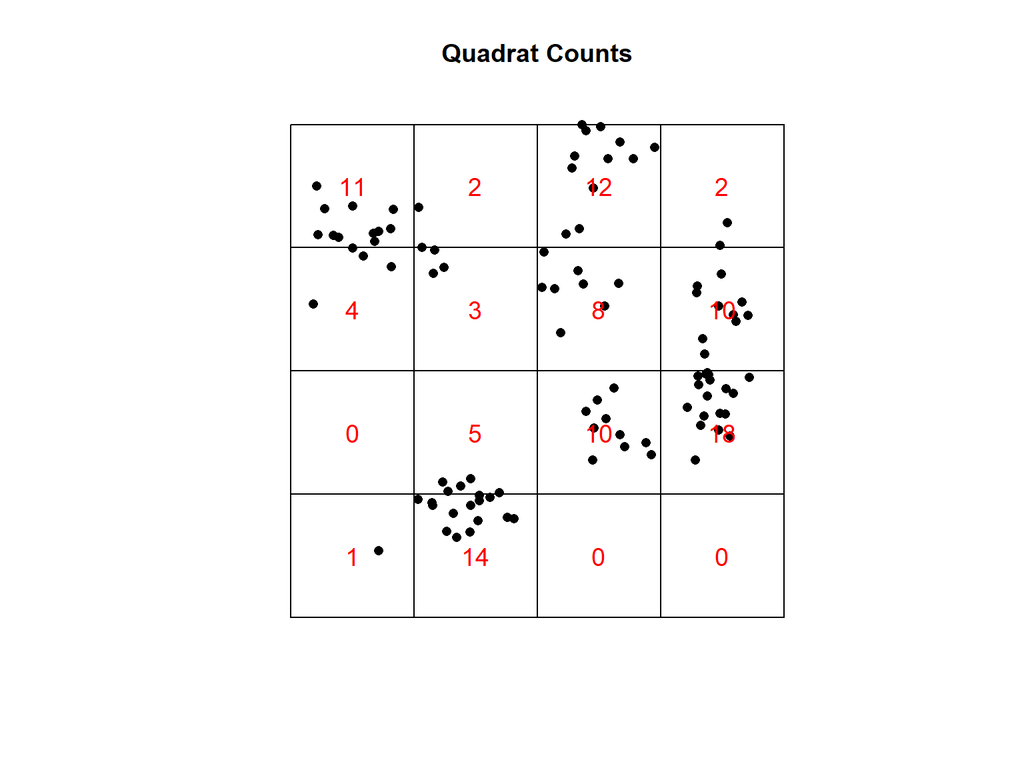

```r
plot(aggregated_ppp, pch = 16, cols = "black", main = "Quadrat Counts")
plot(aggregated_counts, add = TRUE, col = "red", cex = 1.2)
```

### Quadrat Test

```r
aggregated_test <- quadrat.test(aggregated_ppp, nx = 4, ny = 4)
aggregated_test
```

```
##
##  Chi-squared test of CSR using quadrat counts
##
## data:  aggregated_ppp
## X2 = 77.28, df = 15, p-value = 4.375e-10
## alternative hypothesis: two.sided
##
## Quadrats: 4 by 4 grid of tiles
```

The $p$-value is very small, leading to the rejection of $H_0$. The spatial pattern is not consistent with CSR.

# Quadrat Test on an Regular Pattern

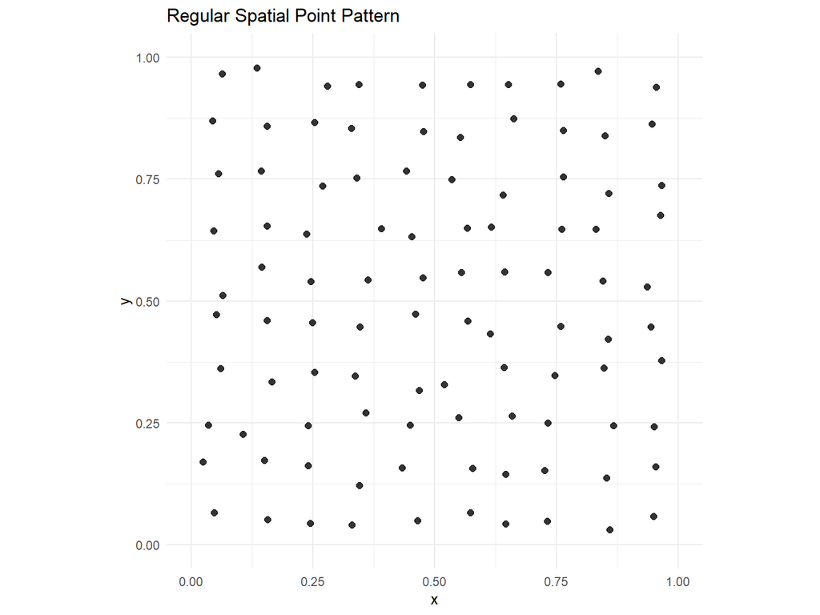

```r
grid_size <- 10

regular_df <- expand.grid(
  x = seq(0.05, 0.95, length.out = grid_size),
  y = seq(0.05, 0.95, length.out = grid_size)
)

regular_df$x <- regular_df$x + rnorm(nrow(regular_df), mean = 0, sd = 0.015)
regular_df$y <- regular_df$y + rnorm(nrow(regular_df), mean = 0, sd = 0.015)
regular_df$pattern <- "Regular"

ggplot(regular_df, aes(x = x, y = y)) +
  geom_point(size = 2, alpha = 0.8) +
  coord_equal(xlim = c(0, 1), ylim = c(0, 1)) +
  labs(
    title = "Regular Spatial Point Pattern",
    x = "x",
    y = "y"
  ) +
  theme_minimal()
```

```r
regular_ppp <- ppp(
  x = regular_df$x,
  y = regular_df$y,
  window = owin(
    xrange = c(0, 1),
    yrange = c(0, 1)
  )
)
regular_ppp
```

```
## Planar point pattern: 100 points
## window: rectangle = [0, 1] x [0, 1] units
```

### Counting

```r
regular_counts <- quadratcount(regular_ppp, nx = 4, ny = 4)
regular_counts
```

```
##             x
## y            [0,0.25] (0.25,0.5] (0.5,0.75] (0.75,1]
##   (0.75,1]          6          8          4        7
##   (0.5,0.75]        6          5          7        7
##   (0.25,0.5]        5          6          8        5
##   [0,0.25]          9          5          6        6
```

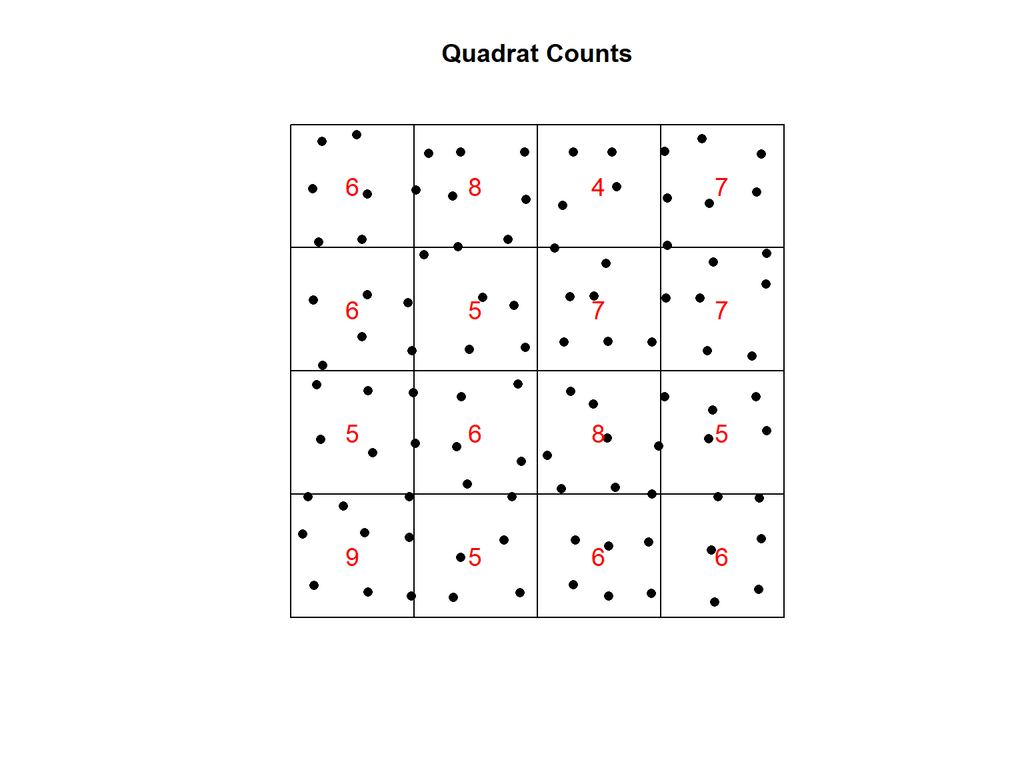

```r
plot(regular_ppp, pch = 16, cols = "black", main = "Quadrat Counts")
plot(regular_counts, add = TRUE, col = "red", cex = 1.2)
```

### Quadrat Test

```r
regular_test <- quadrat.test(regular_ppp, nx = 4, ny = 4)
regular_test
```

```
##
##  Chi-squared test of CSR using quadrat counts
##
## data:  regular_ppp
## X2 = 4.32, df = 15, p-value = 0.007028
## alternative hypothesis: two.sided
##
## Quadrats: 4 by 4 grid of tiles
```

The $p$-value is very small, leading to the rejection of $H_0$. The spatial pattern is not consistent with CSR.

# Alternative Hypothesis

By default, `quadrat.test` tests $H_0: \text{CSR}$ versus $H_a: \text{not CSR}$. If $H_0$ is rejected, we only know it’s not CSR.

To be more specific, we can use one-sided test.

- `alternative = "two.sided"` to test $H_0: \text{CSR}$ versus $H_1: \text{not CSR (regular or aggregated)}$.
- `alternative = "regular"` to test $H_0: \text{CSR}$ versus $H_1: \text{regular}$.
- `alternative = "clustered"` to test $H_0: \text{CSR}$ versus $H_1: \text{aggregated}$.

Using the regular pattern example on the previous page,

```r
one_side_test1 <- quadrat.test(regular_ppp, nx = 4, ny = 4, alternative = "regular")
one_side_test1
```

```
##
##  Chi-squared test of CSR using quadrat counts
##
## data:  regular_ppp
## X2 = 4.32, df = 15, p-value = 0.003514
## alternative hypothesis: regular
##
## Quadrats: 4 by 4 grid of tiles
```

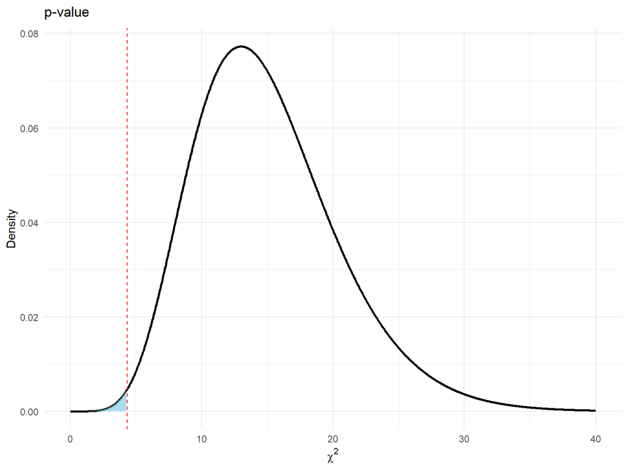

CSR is rejected and we accept a regular pattern.

If we want to test CSR against aggregated, use `alternative = "clustered"`.

```r
one_side_test2 <- quadrat.test(regular_ppp, nx = 4, ny = 4, alternative = "clustered")
one_side_test2
```

```
##
##  Chi-squared test of CSR using quadrat counts
##
## data:  regular_ppp
## X2 = 4.32, df = 15, p-value = 0.9965
## alternative hypothesis: clustered
##
## Quadrats: 4 by 4 grid of tiles
```

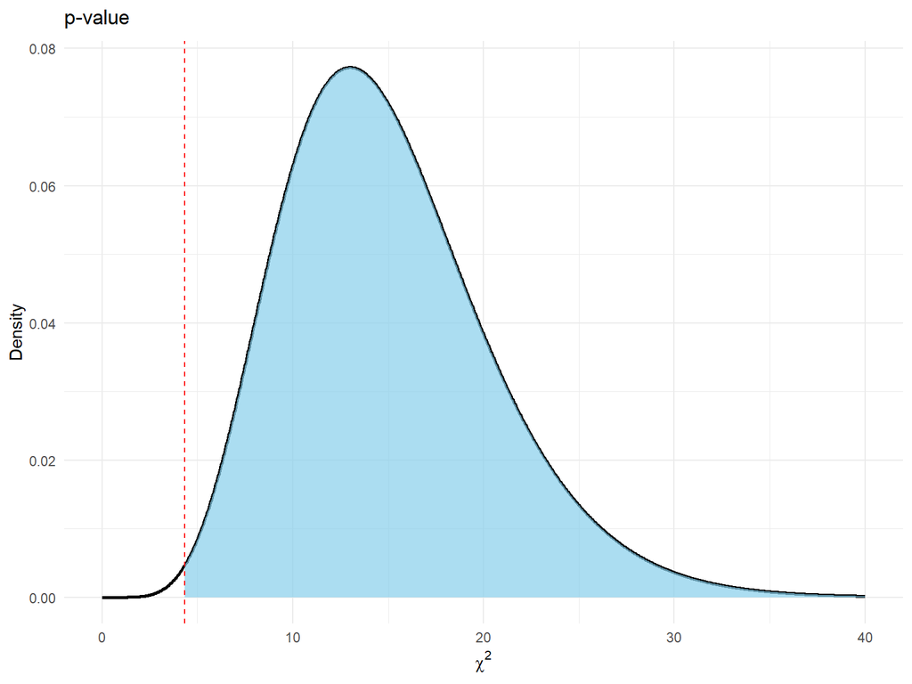

The pattern is not aggregated.